# MPT and Optimal Portfolio Allocation: ETFs & S&P500 Equities

Yu-An(Aaron) Chen

2023-06-29

# Introduction

In the realm of investment management, constructing a well-balanced portfolio that maximizes returns while minimizing risks remains a formidable challenge. To address this, Modern Portfolio Theory (MPT) has emerged as a prominent and empirically grounded framework. This implementation aims to leverage the principles of MPT to create a data-driven investment approach that emphasizes diversification, risk management, and evidence-based decision-making. By focusing on long-term objectives and employing statistical analysis, this implementation seeks to identify optimal portfolio combinations that lie on the efficient frontier, providing investors with superior risk-adjusted returns. Through the implementation of MPT, we endeavor to offer insights that can enhance the rational allocation of assets, instill confidence in investment decisions, and potentially pave the way for more efficient wealth accumulation strategies.

# Implementation Details

This implementation optimizes the following function:

$$\large \min_{\textbf{w}} \textbf{w}^T
\Sigma\textbf{w}$$
Subject to:
$$\large A\textbf{w} \geq b$$
Where

1. $\textbf{w}$ is the vector of asset allocation weights
2. $\Sigma$ is the weighted covariance matrix between different assets
3. $A$ is the matrix representing the inequality constraints
4. $b$ is the vector of constraint bounds.

In other words, this implementation optimizes a portfolio to maximize expected returns and minimize risk. It determines expected returns and risk of each asset based on a weighted measure of its past performance and volatility.

### Important notes:

1. In constructing the weighted covariance matrix between different assets, we used a linear function $f(pastDays) = 2 - pastDays/totalDays$ to determine the weighting between assets on each trading day. This ensures that more recent correlations between assets are taken more into account.
2. A similar approach was used to determine the annual geometric returns. Each annual geometric return is weighted according to the number of years since the start of a user-defined record tracking start date, with weighting ranging from 0.8 to 1.2, scaling linearly. This amplifies the importance of more recent returns, and more closely reflects the current state of the market.
3. This implementation does NOT allow for short selling. That is, allocations cannot go below zero for any asset. This is so users can enjoy a beginner-friendly allocation that still largely achieves its purpose.
4. In the case where there is no possible allocation given the desired return, this implementation will return 0 for all entries. A lottery ticket may be better in those cases :)

# Candidate Assets

In determine which pool of assets to choose from, we landed on the following selections:

1. All stocks in the S&P500 Index excluding ROP (API call issues)
2. Top 100 ETFs by AUM (as of 7/29/2023)
3. Top 40 International ETFs by AUM (as of 7/29/2023)
4. Sector Funds such as GBTC, SMH, SKYY, EWJ, FXI, and USO

This is meant to largely represent the investable portion of the market, but it’s open to change and iterative updates.

# Code Implementation

### API Access & Feature Engineering Functions

```r
percent_difference <- function(old_val, new_val) {
  ((new_val - old_val) / abs(old_val))
}

#Gets info from quantmod API
getInfo = function(tickers, years){
  n = length(tickers)

  # call API
  suppressWarnings(getSymbols(tickers[1], type = "xts"))

  # get prices for this ticker for the last "years" years
  tmp =  tail(get(tickers[1])[,1],252*years)
  # get percent changes over this period
  changes =  percent_difference(matrix(tmp[-1,1]),
                                matrix(tmp[-length(tmp),1]))

  # initialize price / daily change dataframes
  portfolio = data.frame(diff = tmp)
  p_dailyChange = data.frame(changes)
  badNames = c()

  # populate dataframes
  for (name in tickers[-1]){
    getSymbols(name, type = "xts")
    tmp = na.approx(tail(get(name)[,1],252*years))
    if (length(tmp[,1]) < 252*years){
      n = n - 1
      badNames = c(badNames, name)
      next
    }
    changes = percent_difference(matrix(tmp[-1,1]),
                                 matrix(tmp[-length(tmp),1]))
    portfolio = data.frame(portfolio, tmp)
    p_dailyChange = data.frame(p_dailyChange, changes)
  }
  remainingTickers = tickers[!tickers %in% unique(badNames)]
  names(portfolio) = remainingTickers
  names(p_dailyChange) = remainingTickers

  # get weighted covariance matrix of daily returns between tickers, where
  # most recent entry is twice as important as the earliest record.
  covWeights = 2 - c(1:nrow(p_dailyChange))/nrow(p_dailyChange)
  covmatrix = matrix(c(cov.wt(p_dailyChange, wt = covWeights))[[1]],
                     nrow=n, ncol=n)
  dimnames(covmatrix) = list(remainingTickers, remainingTickers)

  geomReturn = function(rowNum){
      prices = portfolio[seq(1,252*years, 252), rowNum]
      returns = c()
      for (i in c(2:length(prices))){
        returns = c(returns, c((prices[i] - prices[i-1])/prices[i-1]))
      }

      returnWeights = seq(0.8, 1.2, length.out = years)
      return(prod(prod(1 + returns, returnWeights))^(1/years) - 1)
  }

  # annual geometric returns for each stock
  avgReturns = round(unlist(lapply(c(1:n),geomReturn)),3)
  names(avgReturns) = remainingTickers

  return(list(avgReturns, covmatrix, remainingTickers))
}
```

### Quadratic Solver & Wrapper Functions

```r
getAllocHelper = function(desiredReturn, estReturns, covmatrix,
                          tickers, principle){
  # set up constrained optimization problem
  n = length(estReturns)
  covmatrix[is.na(covmatrix) | is.infinite(covmatrix)] <- 1
  Dmat = covmatrix
  dvec = rep(0,n)
  Amat = cbind(matrix(estReturns, nrow = n),
               matrix(rep(1, n), nrow = n), diag(n))
  bvec = matrix(c(desiredReturn, 1, rep(0,n)), ncol = 1)

  # first "meq" constraints are equality constraints
  # 1. expected return = desiredReturn
  # 2. sum of weights = 1
  # 3. all weights >= 0
  solution <- tryCatch(list("pass!", solve.QP(Dmat, dvec, Amat, bvec, meq = 2)),
                    error = function(error){
                           noSol = data.frame(matrix(rep(0, 3*length(tickers)),
                                                     ncol = 3))
                           rownames(noSol) = tickers
                           names(noSol) = c("strategy", "allocation", "amount")
                           return(list("error!", noSol))
                             })
  if (solution[[1]] == "error!"){
    return(solution[[2]])
  }
  solution = solution[[2]]

  # extract weighting and fund allocation
  strategy = round(solution$solution, digits = 3)
  allocation = abs(strategy)/sqrt(sum((strategy)^2))
  allocation =  allocation/sum(allocation)

  overallStrat = data.frame(t(rbind(strategy, allocation)))
  rownames(overallStrat) = tickers

  overallStrat = round(overallStrat, 3)

  overallStrat$amount = overallStrat$allocation * principle
  return(overallStrat)
}

getAlloc = function(years, principle, myEst, symbols,
                    baseReturn, desiredReturn, stepSize, actual){

  c(avgReturns, covmatrix, tickers) %<-% getInfo(symbols, years)
  returns = data.frame(Actual = avgReturns, myGuess = myEst)
  if(actual == 1){
    estReturns = avgReturns
  }
  else{
    estReturns = myEst
  }

  # dataframe of allocations for all tickers across all
  # desired return preferences
  targetWeights = data.frame(t(matrix(unlist(
                    mclapply(seq(baseReturn,desiredReturn,stepSize),
                             function(x){
                               return(getAllocHelper(x, estReturns,
                                                    covmatrix, tickers,
                                                    principle)$amount)
                               })), nrow = length(tickers))
                              )
                            )
  names(targetWeights) = tickers

  # additional metrics: variance & achieved estimated return
  portfolio_variance <- round(apply(targetWeights, 1,
                              function(row){
                                return(sqrt(t(row/principle)%*%
                                              covmatrix%*%row/principle))}), 4)
  est_return <- round(apply(targetWeights, 1,
                              function(row){
                                return((row%*%estReturns)/principle)}), 2)

  output = data.frame(est_return = est_return,
                      dailyRisk_sd = portfolio_variance,
                    targetWeights[,rev(order(apply(targetWeights,
                                                   2, which.max)))])

  all_zeros_columns <- colSums(output) == 0
  output = data.frame(subset(output, select = !all_zeros_columns))
  rownames(output) = NULL

  return(output)
}
```

### Webscraping & Aggregating Tickers

```r
page <- read_html("https://etfdb.com/compare/market-cap/")
page2 = read_html("https://www.slickcharts.com/sp500")
page3 = read_html(
      "https://etfdb.com/index/msci-all-country-world-ex-us-growth-index/")


etf_table <- c(data.frame(html_table(html_nodes(page, "table")[[1]],
                                   fill = TRUE)))[[1]]
sp500_table = c(data.frame(html_table(html_nodes(page2, "table")[[1]],
                                    fill = TRUE)))[[3]]
int_etfs = c(c(data.frame(
  html_table(html_nodes(page3, "table")[[1]], fill = TRUE))[-11,])[[1]],
  "VXUS", "BNDX", "VEU", "IXUS", "VSS", "VYMI", "DFAX", "VIGI", "IAGG", "ACWX",
  "VNQI", "VSGX", "CWI", "CGXU", "PID", "BWX", "SCHY", "IGRO", "HAUZ", "DNL",
  "IQDF", "DWX", "WIP", "GXUS", "VIDI", "JPIB")

tickers = unique(c(int_etfs, etf_table, "GBTC", "SMH", "SKYY", "EWJ",
                   "FXI","USO", gsub("\\.", "-",sp500_table)))
exclude = c("ROP")
tickers = tickers[!tickers %in% exclude]
```

### Executing Program

Now we will, following Modern Portfolio Theory, determine the optimal portfolios across expected returns from 4% to 50%. As an example, we will designate the data collection look-back period to be 8 years and a total of $10000USD to allocate to the assets.

```r
optimalAlloc = getAlloc(years = 8, principle = 10000,
                        myEst = NA, symbols = tickers,
                        baseReturn = 0.04, desiredReturn = 0.50,
                        stepSize = 0.02, actual = 1)

kable_styling(kable(optimalAlloc),bootstrap_options = "striped") %>%
  scroll_box(width = "900px", height = "650px")
```

| est_return | dailyRisk_sd | ENPH | AMD | NVDA | GBTC | CPRT | UNH | AWK | CDNS | LLY | NEE | PGR | WST | RSG | ODFL | WM | TMUS | IAU | TLT | COST | VGSH | HSY | SHV | BIL |
| --- | --- | --- | --- | --- | --- | --- | --- | --- | --- | --- | --- | --- | --- | --- | --- | --- | --- | --- | --- | --- | --- | --- | --- | --- |
| 0.04 | 0.0020 | 40 | 120 | 200 | 60 | 120 | 100 | 20 | 50 | 180 | 30 | 130 | 50 | 210 | 40 | 40 | 50 | 440 | 210 | 30 | 190 | 10 | 5040 | 2640 |
| 0.06 | 0.0028 | 60 | 180 | 290 | 80 | 170 | 140 | 40 | 70 | 250 | 50 | 180 | 70 | 300 | 60 | 60 | 70 | 620 | 310 | 40 | 260 | 10 | 5110 | 1590 |
| 0.08 | 0.0036 | 80 | 230 | 370 | 100 | 220 | 190 | 50 | 80 | 320 | 60 | 230 | 90 | 380 | 80 | 70 | 90 | 800 | 400 | 50 | 330 | 10 | 5230 | 540 |
| 0.10 | 0.0044 | 90 | 280 | 450 | 120 | 270 | 230 | 60 | 100 | 400 | 70 | 280 | 110 | 460 | 100 | 90 | 110 | 980 | 490 | 70 | 410 | 10 | 4810 | 0 |
| 0.12 | 0.0052 | 110 | 330 | 540 | 150 | 320 | 270 | 70 | 120 | 470 | 80 | 330 | 130 | 550 | 120 | 110 | 130 | 1160 | 590 | 80 | 480 | 10 | 3850 | 0 |
| 0.14 | 0.0061 | 130 | 380 | 620 | 170 | 370 | 310 | 90 | 140 | 550 | 90 | 380 | 150 | 630 | 140 | 120 | 150 | 1340 | 680 | 100 | 550 | 20 | 2890 | 0 |
| 0.16 | 0.0068 | 140 | 430 | 700 | 190 | 420 | 350 | 100 | 160 | 620 | 100 | 430 | 170 | 720 | 160 | 140 | 170 | 1520 | 780 | 110 | 620 | 20 | 1940 | 0 |
| 0.18 | 0.0077 | 160 | 480 | 790 | 210 | 470 | 390 | 110 | 180 | 690 | 120 | 490 | 200 | 800 | 170 | 150 | 190 | 1710 | 870 | 130 | 690 | 20 | 980 | 0 |
| 0.20 | 0.0085 | 180 | 530 | 870 | 240 | 520 | 430 | 120 | 190 | 770 | 130 | 540 | 220 | 890 | 190 | 170 | 210 | 1890 | 970 | 140 | 770 | 20 | 30 | 0 |
| 0.22 | 0.0093 | 200 | 590 | 960 | 260 | 570 | 470 | 150 | 210 | 840 | 140 | 580 | 240 | 930 | 210 | 190 | 220 | 2060 | 1040 | 130 | 0 | 10 | 0 | 0 |
| 0.24 | 0.0101 | 230 | 670 | 1080 | 300 | 620 | 510 | 190 | 260 | 890 | 180 | 580 | 250 | 920 | 210 | 180 | 190 | 2020 | 680 | 40 | 0 | 0 | 0 | 0 |
| 0.26 | 0.0110 | 260 | 760 | 1210 | 340 | 670 | 540 | 220 | 300 | 950 | 220 | 580 | 250 | 900 | 200 | 150 | 160 | 1970 | 310 | 0 | 0 | 0 | 0 | 0 |
| 0.28 | 0.0119 | 300 | 840 | 1330 | 380 | 710 | 570 | 250 | 330 | 1000 | 250 | 580 | 250 | 880 | 200 | 120 | 120 | 1870 | 0 | 0 | 0 | 0 | 0 | 0 |
| 0.30 | 0.0128 | 340 | 940 | 1470 | 430 | 770 | 610 | 280 | 360 | 1050 | 260 | 580 | 240 | 820 | 200 | 110 | 50 | 1490 | 0 | 0 | 0 | 0 | 0 | 0 |
| 0.32 | 0.0137 | 390 | 1040 | 1620 | 480 | 830 | 640 | 300 | 390 | 1100 | 260 | 590 | 220 | 750 | 200 | 100 | 0 | 1100 | 0 | 0 | 0 | 0 | 0 | 0 |
| 0.34 | 0.0147 | 430 | 1140 | 1770 | 530 | 880 | 670 | 320 | 420 | 1140 | 260 | 580 | 200 | 680 | 190 | 80 | 0 | 690 | 0 | 0 | 0 | 0 | 0 | 0 |
| 0.36 | 0.0156 | 480 | 1240 | 1900 | 580 | 940 | 700 | 340 | 450 | 1190 | 270 | 580 | 180 | 610 | 190 | 60 | 0 | 290 | 0 | 0 | 0 | 0 | 0 | 0 |
| 0.38 | 0.0166 | 530 | 1340 | 2060 | 630 | 990 | 720 | 350 | 470 | 1230 | 240 | 570 | 150 | 510 | 180 | 20 | 0 | 0 | 0 | 0 | 0 | 0 | 0 | 0 |
| 0.40 | 0.0176 | 590 | 1470 | 2270 | 690 | 1030 | 730 | 310 | 470 | 1220 | 130 | 530 | 100 | 300 | 160 | 0 | 0 | 0 | 0 | 0 | 0 | 0 | 0 | 0 |
| 0.42 | 0.0186 | 650 | 1600 | 2480 | 740 | 1080 | 730 | 270 | 470 | 1210 | 20 | 490 | 40 | 70 | 130 | 0 | 0 | 0 | 0 | 0 | 0 | 0 | 0 | 0 |
| 0.44 | 0.0197 | 720 | 1730 | 2700 | 800 | 1100 | 700 | 110 | 470 | 1190 | 0 | 400 | 0 | 0 | 90 | 0 | 0 | 0 | 0 | 0 | 0 | 0 | 0 | 0 |
| 0.46 | 0.0208 | 780 | 1870 | 2930 | 860 | 1100 | 630 | 0 | 440 | 1120 | 0 | 250 | 0 | 0 | 20 | 0 | 0 | 0 | 0 | 0 | 0 | 0 | 0 | 0 |
| 0.48 | 0.0219 | 850 | 2020 | 3170 | 920 | 1060 | 520 | 0 | 390 | 1020 | 0 | 50 | 0 | 0 | 0 | 0 | 0 | 0 | 0 | 0 | 0 | 0 | 0 | 0 |
| 0.50 | 0.0230 | 920 | 2170 | 3420 | 980 | 980 | 350 | 0 | 310 | 870 | 0 | 0 | 0 | 0 | 0 | 0 | 0 | 0 | 0 | 0 | 0 | 0 | 0 | 0 |

# Visualizations

### Efficient Frontier

Now with the optimal allocations, we can visualize the relationship between expected annual returns and portfolio variance.

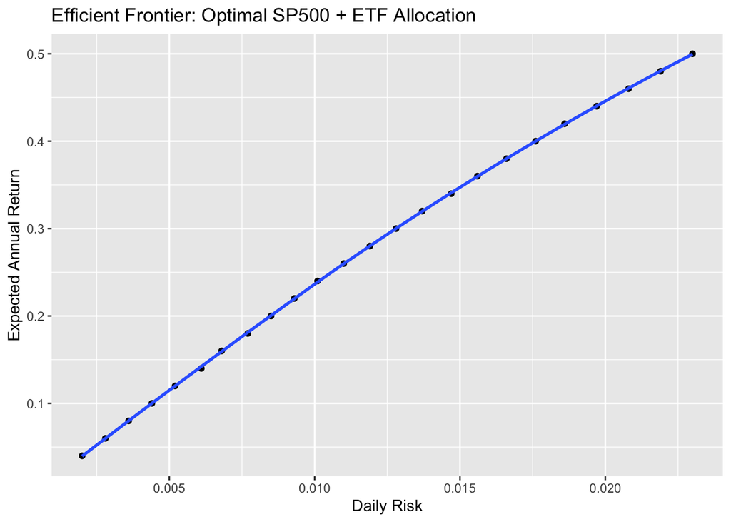

```r
ggplot(optimalAlloc, aes(y = est_return, x = dailyRisk_sd)) + geom_point() +
  geom_smooth(method = "loess", formula = y~x, se = FALSE) +
  labs(x = "Daily Risk", y = "Expected Annual Return",
       title = "Efficient Frontier: Optimal SP500 + ETF Allocation")
```

From the plot above, we observe that the efficient frontier line demonstrates a positive correlation between daily portfolio risk and expected returns, which is to be expected – the higher the expected return, the higher the portfolio risk. Any point on this line represents an optimal possible allocation of assets given an investors risk tolerance.

To demonstrate the potential upsides and downsides of a portfolio that lies on this line, we will explore the risk and reward profile of a hypothetical growth investor seeking an expected annual return of 15% in the next section.

### EOY Return Simluations

To simulate this, we will assume daily returns follow a normal distribution with mean = 1.00055 (so annual returns average 0.15) and has the previously stated standard deviation of 0.0068. We will draw 252 samples from this distribution and determine the resulting return after the simulated 252 trading days in a year. We then repeat this process 30000 times to determine the distribution of possible outcomes from following this variance minimizing allocation strategy.

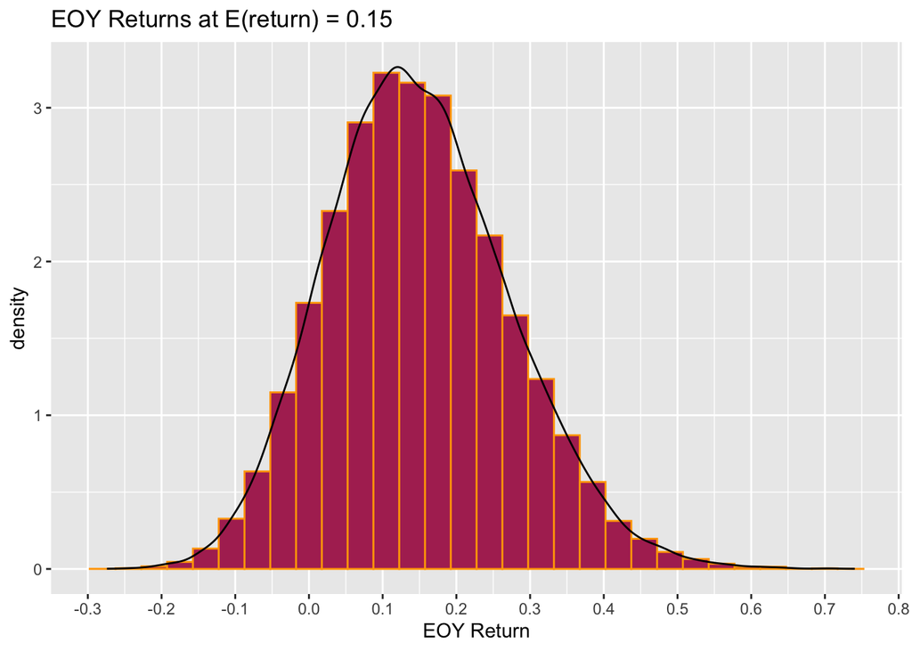

```r
principle = 10000
balance = c(principle)
endBalance = c()
for (i in c(1:30000)){
  balance = c(principle)
   for (change in rnorm(252, 1.00055, sd = 0.0068)){
    balance = c(balance, tail(balance,1)*change)
   }
  endBalance = c(endBalance, tail(balance,1))
}

endReturn = (endBalance - principle)/principle

ggplot(data.frame(endReturn), aes(x = endReturn)) +
  geom_histogram(aes(y = after_stat(density)),
                 fill = "maroon", color = "orange", bins = 30) +
  scale_x_continuous(n.breaks = 15) +
  geom_density() +
  labs(x = "EOY Return", title = "EOY Returns at E(return) = 0.15")
```

```r
lossProb = length(which(endReturn < 0.02))/length(endReturn)

#SPY Avg gain over last 8 years = 11.66%
gainProb = length(which(endReturn > 0.1166))/length(endReturn)
```

As shown, this risk-reward portfolio profile can lead to returns ranging from -30% to +80%. This demonstrates that even when achieving minimum variance, having a portfolio with expected daily return standard deviation of 0.68% can still lead to significant negative returns. In fact, according to this model, there is a ~14.8% chance in expectation that a hypothetical investor with this portfolio does not beat inflation of 2% in a year. However, this risk is compensated by a ~58% probability that this allocation will beat the S&P500 index in returns in a year. Overall, this plot provides a theoretical lower bound visualization on the variance of EOY returns of a portfolio given previously stated parameters and risk tolerance – it serves as a useful guideline approximation on real-world potential returns.

# Use Case & Limitations

There are plenty of use cases for these optimal allocation given an investor’s risk tolerance, namely:

1. Serving as a guideline for rebalancing one’s portfolio
2. Testing optimal allocations with certain assets pre-established
3. Managing risk/rewards given simulated return scenarios

However, there are a few key assumptions that one should keep in mind about utilizing MPT, namely:

1. Expected returns of each asset are calculated from weighted past performance
2. Associations between assets over time remain the same
3. Slight bias towards assets that have performed exceptionally well in recent years

To address these issues, this implementation has introduced a new parameter, “myEst”, where users can define their estimated returns for each asset independent of past performance. Note that changing this parameter will not alter the covariance matrix, but will likely alter the resulting allocation weights for different assets.

Even with this in mind, it’s important to note the optimal allocations should on be used as a reference instead of pure truth. It doesn’t account for real world events nor circumstances and any output should therefore be interpreted with a large grain of salt.

# Conclusion

In this implementation, we provided a weighted covariance and geometric return approach to the MPT optimization problem. We were able to show the optimal allocations given S&P500 equities, top ETFs, and specific sector funds as candidate assets. We also showed the risk reward profile of an hypothetical investor with goals of an 15% expected annual return. In terms of next steps, we hope to incorporate analyst estimates on the stocks as a factor in estimating expected returns to obtain a more comprehensive view on an asset’s outlook.

Special thanks to Professor O. at Rice University on Coursera for motivating this mini-project!